# QC Analysis of ICB Wolf mae

Nasim Bondar Sahebi

UofT student, Princess Margaret Cancer Center,University Health Network, Toronto, Ontario, Canada

2024 01 23

## load libraries

```r
library(MultiAssayExperiment)
library(ggplot2)
library(dplyr)
library(tibble)
library(patchwork)
library(networkD3)
```

## Data Loading and Preparation

**Data Overview**:

- **Study Reference**: [PubMed ID 35623341](https://pubmed.ncbi.nlm.nih.gov/35623341/)
- **Patient Count (RNA)**: 987
- **Treatment Details**:
- **IO+chemo**: 69
- **chemo+targeted**: 687
- **chemo**: 179
- **targeted**: 52

Load multiassay .rds file, extract clinical, expression and annotations data; prepare gene expression data for analysis.

```r
# Load your multiassay result and extract clinical data , expression data and annotation

#load mae obj
mae <- readRDS("~/BHK lab/ICB_Wolf/output/ICB_Wolf.rds")

#extract Clinical data
clin <- data.frame(colData(mae)) # Dim 987 x85

#extract the expression data
expr <- assays(mae)[["expr"]] # Dim 18348 x 987

#extracting the annotation
annot <- data.frame(rowData(mae@ExperimentList$expr))

# Display first few rows of the data set.
DT::datatable(expr[1:8, 1:4])
```

|  | X756412 | X111881 | X451816 | X243836 |
| --- | --- | --- | --- | --- |
| ENSG00000000003.10 | 9.2058 | 7.5586 | 7.0909 | 8.8402 |
| ENSG00000000005.5 | 4.6488 | 4.2792 | 5.0983 | 5.0612 |
| ENSG00000000419.8 | 12.258 | 12.816 | 12.722 | 12.975 |
| ENSG00000000457.9 | 9.9888 | 9.1309 | 8.7602 | 8.7112 |
| ENSG00000000460.12 | 9.2978 | 8.5738 | 8.7915 | 9.1821 |
| ENSG00000000938.8 | 7.5326 | 8.0202 | 8.0026 | 8.5236 |
| ENSG00000000971.11 | 8.721 | 8.3135 | 8.3359 | 9.218 |
| ENSG00000001036.9 | 7.6301 | 8.9642 | 8.6309 | 8.8627 |

## Treatment checking

- Our analysis confirms `Arm..short.name.` from the paper’s dataset matches with the `treatmentid` in our dataset, as defined by the `Format_CLIN.R` function from scripts.

```r
# Display counts for specific treatments(IO)
cat("Paclitaxel + Pembrolizumab treatments:", nrow(clin[clin$treatmentid == "Paclitaxel + Pembrolizumab", ]), "\n")
```

```
## Paclitaxel + Pembrolizumab treatments: 69
```

```r
cat("IO+chemo treatments:", nrow(clin[clin$treatment == "IO+chemo", ]), "\n")
```

```
## IO+chemo treatments: 69
```

```r
cat("Pembro treatments:", nrow(clin[clin$Arm..short.name. == "Pembro", ]), "\n")
```

```
## Pembro treatments: 69
```

```r
# Check if all 'Pembro' entries match 'IO+chemo' in treatment and 'Paclitaxel + Pembrolizumab' in treatmentid
pembro_data <- clin[clin$Arm..short.name. == "Pembro", ]

cat("All 'Pembro' match 'IO+chemo':", all(pembro_data$treatment == "IO+chemo"), "\n")
```

```
## All 'Pembro' match 'IO+chemo': TRUE
```

```r
cat("All 'Pembro' match 'Paclitaxel + Pembrolizumab':", all(pembro_data$treatmentid == "Paclitaxel + Pembrolizumab"), "\n")
```

```
## All 'Pembro' match 'Paclitaxel + Pembrolizumab': TRUE
```

## Paper Fig1: Trial design and data.

**PCR rate across arms by receptor subtype:** - PCR and arms is stored in column `pCR` and which was set in `Format_CLIN.R`. - Arm is stored in column `Arm..short.name.` column - PCR rate is stored `Receptor.Subtype` column

**Results**: Comparing our findings to those from paper Figure 1(c):

- **HR-HER2+ subtype**: The paper presents a top pCR rate of 74%, followed by 64%, 62%, and 56%, in contrast to our findings of 80%, 71%, 67%, and 57% respectively.
- **HR+HER2- subtype**: The paper reports a peak pCR rate of 30%; our data shows approximately 30% as well.
- **HR+HER2+ subtype**: A discrepancy is observed; the paper notes a 46% pCR rate, followed by 44%, while our results suggest a higher rate of around 51% and 48%.
- **HR-HER2- (TN) subtype**: The paper presents a top pCR rate of 60% followed by 51%, our findings are 66% and 56% respectively

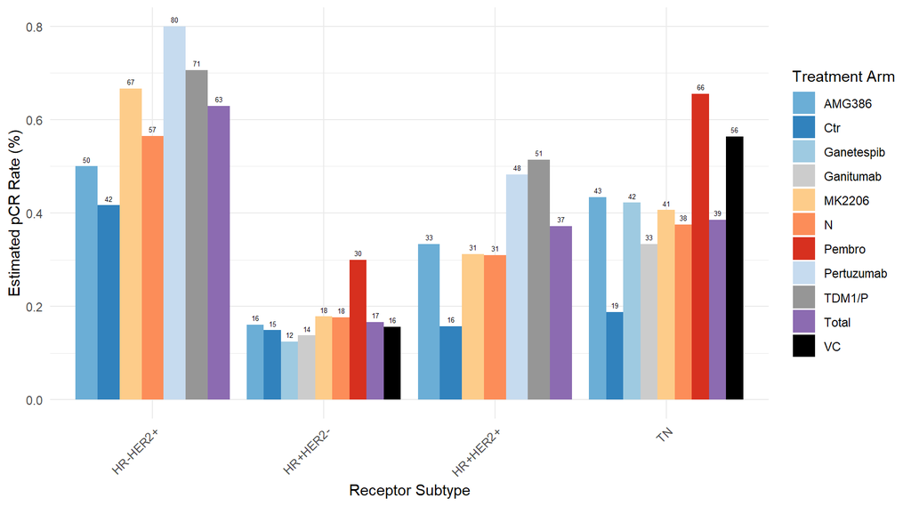

```r
# Calculate the mean pCR rate for each treatment arm and receptor subtype
pCR_rates <- aggregate(pCR ~ Arm..short.name. + Receptor.Subtype, data = clin, FUN = mean)

# Calculate the total for each Receptor.Subtype, assuming totals are already in the correct format
totals <- aggregate(pCR ~ Receptor.Subtype, data = clin, FUN = mean)
totals$Arm..short.name. <- "Total"

# Combine the mean percentages and the totals
pCR_rates_with_totals <- rbind(pCR_rates, totals)

# Define some colours for later use.
colors <- c("#6BAED6", "#3182BD", "#9ECAE1", "#CCCCCC", "#FDCC8A", "#FC8D59", "#D7301F", "#C6DBEF", "#969696", "#8C6BB1", "black", "#BADA55")

# Define a ggplot object with a bar plot
ggplot_object <- ggplot(pCR_rates_with_totals, aes(x = Receptor.Subtype, y = pCR, fill = Arm..short.name.)) +
  geom_bar(stat = "identity", position = position_dodge()) +
  geom_text(aes(label = paste0(round(pCR, 2)*100)),
            position = position_dodge(width = 0.9),
            vjust = -0.7,
            color = "black",
            size = 1.7) +
  scale_fill_manual(values = colors) +
  labs(x = "Receptor Subtype", y = "Estimated pCR Rate (%)", fill = "Treatment Arm") +  theme_minimal() +
  theme(axis.text.x = element_text(angle = 45, hjust = 1))

print(ggplot_object )
```

**ISPY2–990 mRNA/RPPA Data Resource consort**

**Results**: Comparing our findings to those from paper Figure 1(d):

- We observe that the bar plot results from contain the exact same information as Figure 1(d) in the paper.

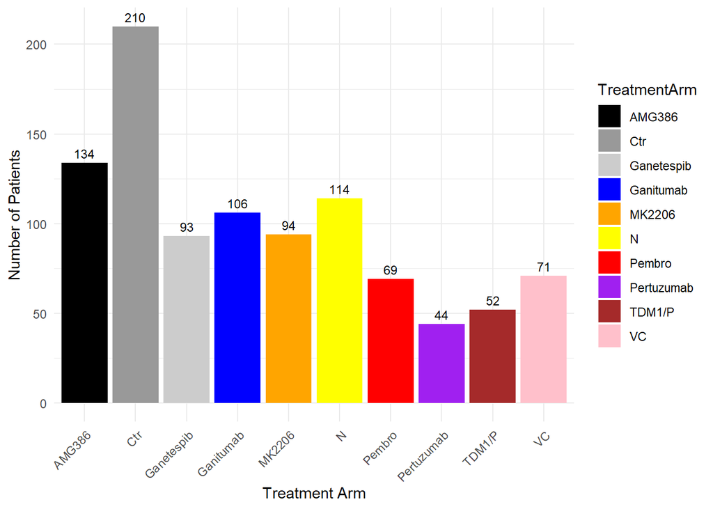

```r
#2.Part d

# Create a data frame with the number of patients for each treatment arm
arm_counts_df<- as.data.frame(table(clin$Arm..short.name.))

# Define colours for later.
colors <- c("black", "grey60", "grey80", "blue", "orange", "yellow", "red", "purple", "brown", "pink")

# Rename the columns for clarity
names(arm_counts_df) <- c("TreatmentArm", "NumberOfPatients")

# define the bar plot
ggplot <- ggplot(arm_counts_df, aes(x = TreatmentArm, y = NumberOfPatients, label = NumberOfPatients)) +
  geom_bar(stat = "identity", aes(fill = TreatmentArm)) + geom_text(vjust = -0.5, size = 3) +
  scale_fill_manual(values = colors) + labs(x = "Treatment Arm", y = "Number of Patients") +
  theme_minimal() +theme(axis.text.x = element_text(angle = 45, hjust = 1))

# Display the plot
print(ggplot)
```

```r
# Print the dimensions of the 'clin'  and verify with the paper results
cat("Dimensions of 'clin':", paste(dim(clin)),
    "\nFigure 1d, section 'ISPY-990 mRNA/PPA DATA' of the paper also mentions Clinical data number is (n=987)\n\n")
```

```
## Dimensions of 'clin': 987 86
## Figure 1d, section 'ISPY-990 mRNA/PPA DATA' of the paper also mentions Clinical data number is (n=987)
```

```r
# Print the dimensions of the 'expr'
cat("Dimensions of 'expr':", paste(dim(expr)), "\n")
```

```
## Dimensions of 'expr': 18348 987
```

```r
# Print the number of unique treatment arms in the 'clin'
cat("Number of unique 'arm' values in 'clin':", length(unique(clin$Arm..short.name.)), "\n")
```

```
## Number of unique 'arm' values in 'clin': 10
```

```r
cat("The paper mentions mRNA data has 987 patients with almost 19,000 genes across all 10 arms\n")
```

```
## The paper mentions mRNA data has 987 patients with almost 19,000 genes across all 10 arms
```

## Paper Fig4: Clinically motivated response-based biomarker-subsets.

**Overall prevalence and pCR rates in Pembro by immune subtype in TN:**

**Results**: Comparing our findings to those from paper Figure 4(a):

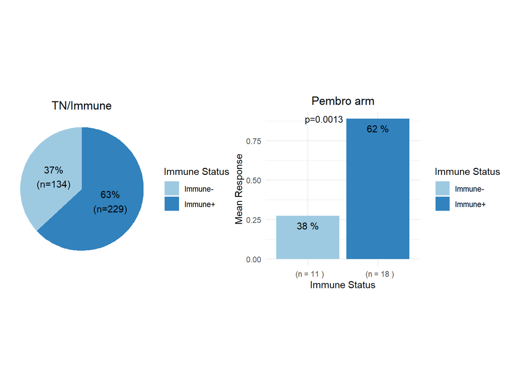

```r
# Part (a)
# 1. Pie chart for TN samples

# subset TN samples
clin_TN <- clin[clin$Receptor.Subtype == "TN",]

# Define data.frame for Immune Status and Counts
clin_Immune <- as.data.frame(table(clin_TN$Immune.))
names(clin_Immune) <- c("Immune_Status", "Counts")

# Rename the 0 and 1 to "Immune-" and "Immune+"
clin_Immune$Immune_Status <- factor(clin_Immune$Immune_Status, levels = c("0", "1"), labels = c("Immune-", "Immune+"))

# Define a pie chart
pie_chart <- ggplot(clin_Immune, aes(x = "", y = Counts, fill = Immune_Status)) +
  geom_bar(stat = "identity", width = 1) +
  coord_polar("y", start = 0) +
  theme_void() +
  scale_fill_manual(values = c("#9ECAE1", "#3182BD")) +
  geom_text(aes(label = paste0(round(Counts / sum(Counts) * 100), "%", "\n(n=", Counts, ")")),
            position = position_stack(vjust = 0.5)) +
  labs(title = "TN/Immune", fill = "Immune Status") +
  theme(plot.title = element_text(hjust = 0.5))

# Part (b)
# 2. Barplot for TN samples

# Filter clin_TN to include only the Pembro arm
clin_TN_pembro <- clin_TN[clin_TN$Arm..short.name. == "Pembro",]

# Calculate mean pCR values for each Immune Status in the Pembro arm
response_data <- aggregate(pCR ~ Immune., data = clin_TN_pembro, FUN = mean, na.rm = TRUE)
names(response_data) <- c("Immune_Status", "Mean_Response")
response_data$Counts <- aggregate(pCR ~ Immune., data = clin_TN_pembro, FUN = length)$pCR

# Add a new column to the data frame with the percentages
response_data$Percentage <- (response_data$Counts / sum(response_data$Counts)) * 100

# Convert Immune_Status to a factor with more readable levels
response_data$Immune_Status <- factor(response_data$Immune_Status, levels = c("0", "1"), labels = c("Immune-", "Immune+"))

# Set labels for format immune status and counts
response_data$Labels <- paste(response_data$Immune., " (n =", response_data$Counts, ")")

# Define  bar chart
bar_chart <- ggplot(response_data, aes(x = Labels, y = Mean_Response, fill = Immune_Status)) +
  geom_bar(stat = "identity") +
  geom_text(aes(label = paste(round(Percentage), "%")), vjust = 1.8, color = "black") +
  labs(x = "Immune Status", y = "Mean Response", fill = "Immune Status") +
  scale_fill_manual(values = c("#9ECAE1", "#3182BD")) +
  theme_minimal() +
  ggtitle("Pembro arm") +
  theme(plot.title = element_text(hjust = 0.5))


# Perform to extract p-value
fisher_result <- fisher.test(table(clin_TN_pembro$pCR, clin_TN_pembro$Immune.))
p_value <- round(fisher_result$p.value, 4)

# Annotate the p-value on the bar chart
bar_chart <- bar_chart +
  annotate("text", x = 1.5, y = max(response_data$Mean_Response, na.rm = TRUE),
           label = paste0("p=", p_value), size = 3.5, hjust = 1 )

print(pie_chart + bar_chart )
```

**Part(b)**:

**Checking Overall prevalence and pCR rates in VC by DRD subtype in TN. p-values shown are from Fisher’s exact test**

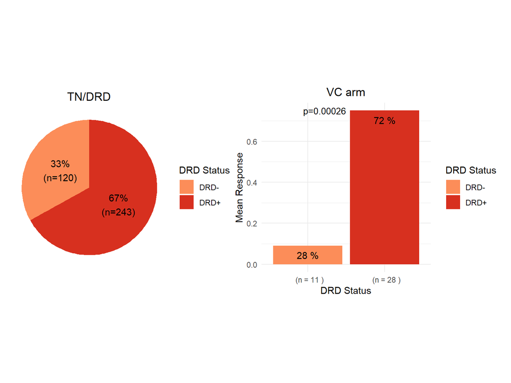

```r
# Part (a)
# 1. Pie chart for TN samples based on DRD status

# subset TN samples
clin_TN <- clin[clin$Receptor.Subtype == "TN",]

# Define data.frame for DRD Status and Counts
clin_DRD <- as.data.frame(table(clin_TN$DRD.))
names(clin_DRD) <- c("DRD_Status", "Counts")

# Rename the 0 and 1 to "DRD-" and "DRD+"
clin_DRD$DRD_Status <- factor(clin_DRD$DRD_Status, levels = c("0", "1"), labels = c("DRD-", "DRD+"))

# Define a pie chart for DRD status
pie_chart_DRD <- ggplot(clin_DRD, aes(x = "", y = Counts, fill = DRD_Status)) +
  geom_bar(stat = "identity", width = 1) +
  coord_polar("y", start = 0) +
  theme_void() +
  scale_fill_manual(values = c("#FC8D59", "#D7301F")) +
  geom_text(aes(label = paste0(round(Counts / sum(Counts) * 100), "%", "\n(n=", Counts, ")")),
            position = position_stack(vjust = 0.5)) +
  labs(title = "TN/DRD", fill = "DRD Status") +
  theme(plot.title = element_text(hjust = 0.5))

# Part (b)
# 2. Barplot for TN samples based on DRD status for VC arm

# Filter clin_TN to include only the VC arm
clin_TN_VC <- clin_TN[clin_TN$Arm..short.name. == "VC",]

# Calculate mean pCR values for each DRD Status in the VC arm
response_data_VC <- aggregate(pCR ~ DRD., data = clin_TN_VC, FUN = mean, na.rm = TRUE)
names(response_data_VC) <- c("DRD_Status", "Mean_Response")
response_data_VC$Counts <- aggregate(pCR ~ DRD., data = clin_TN_VC, FUN = length)$pCR

# Add a new column to the data frame with the percentages
response_data_VC$Percentage <- (response_data_VC$Counts / sum(response_data_VC$Counts)) * 100

# Convert DRD_Status to a factor with more readable levels
response_data_VC$DRD_Status <- factor(response_data_VC$DRD_Status, levels = c("0", "1"), labels = c("DRD-", "DRD+"))

# Set labels for format DRD status and counts
response_data_VC$Labels <- paste(response_data_VC$DRD., " (n =", response_data_VC$Counts, ")")

# Define bar chart for DRD status in the VC arm
bar_chart_DRD_VC <- ggplot(response_data_VC, aes(x = Labels, y = Mean_Response, fill = DRD_Status)) +
  geom_bar(stat = "identity") +
  geom_text(aes(label = paste(round(Percentage), "%")), vjust = 1.8, color = "black") +
  labs(x = "DRD Status", y = "Mean Response", fill = "DRD Status") +
  scale_fill_manual(values = c("#FC8D59", "#D7301F")) +
  theme_minimal() +
  ggtitle("VC arm") +
  theme(plot.title = element_text(hjust = 0.5))

# Perform Fisher's exact test
fisher_result_DRD_VC <- fisher.test(table(clin_TN_VC$pCR, clin_TN_VC$DRD.))
p_value_DRD_VC <- round(fisher_result_DRD_VC$p.value, 5)

# Annotate the p-value on the DRD bar chart for the VC arm
bar_chart_DRD_VC <- bar_chart_DRD_VC +
  annotate("text", x = 1.5, y = max(response_data_VC$Mean_Response, na.rm = TRUE),
           label = paste0("p=", sprintf("%.5f", p_value_DRD_VC)), size = 3.5, hjust = 1 )


# Combine the DRD pie chart and VC arm DRD bar chart
print(pie_chart_DRD + bar_chart_DRD_VC)
```

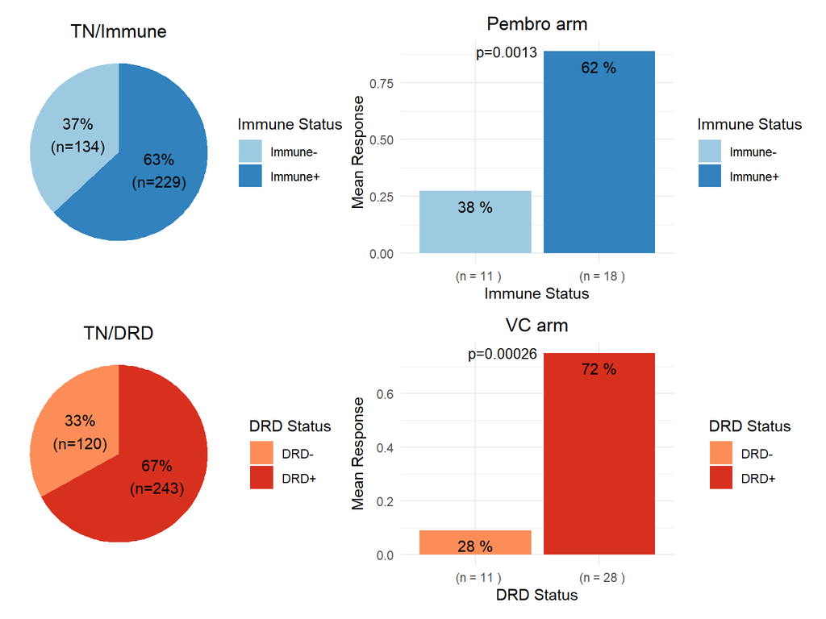

```r
# Combine the piercharts and bar plots
print(pie_chart + bar_chart + pie_chart_DRD + bar_chart_DRD_VC )
```

**Part(c)**:

**Sankey plot showing Immune/DRD subsets in TN, with barplots of pCR rates in VC, Pembro and control.**

**Results**: Comparing our findings to those from paper Figure 4(c):

- We observe that the bar plot results contain the exact same information as Figure 4(c) in the paper.

```r
# Use clin_TN subset

# Define count of "HR-HER2+", "HR+HER2", "HER2+/BP-HER2_or_Basal" , ""HER2+/BP-Luminal" an dTotal number of rows for defining the percentages.
TN_count <- nrow(clin_TN)
Immune_neg_DRD_neg_count <- sum(clin_TN$RPS.5 == "HER2-/Immune-/DRD.v3-", na.rm = TRUE)
Immune_neg_DRD_pos_count <- sum(clin_TN$RPS.5 == "HER2-/Immune-/DRD.v3+", na.rm = TRUE)
Immune_pos_DRD_neg_count <- sum(clin_TN$RPS.5 == "HER2-/Immune+" & clin_TN$DRD. == "0", na.rm = TRUE)
Immune_pos_DRD_pos_count <- sum(clin_TN$RPS.5 == "HER2-/Immune+"& clin_TN$DRD. == "1", na.rm = TRUE)


# Example format: "HR-HER2+; 30% (n=100)"
nodes <- data.frame(name = c(
  paste("TN;","(n=",  nrow(clin_TN), ")", sep=""),
  paste("TN/Immune-/DRD+;", ceiling(Immune_neg_DRD_neg_count  / TN_count * 100), "% (n=", Immune_neg_DRD_neg_count, ")", sep=""),
  paste("TN/Immune-/DRD-;", ceiling(Immune_neg_DRD_pos_count / TN_count * 100), "% (n=", Immune_neg_DRD_pos_count, ")", sep=""),
  paste("TN/Immune+/DRD-;", ceiling(Immune_pos_DRD_neg_count / TN_count * 100), "% (n=", Immune_pos_DRD_neg_count, ")", sep=""),
   paste("TN/Immune+/DRD+;", ceiling(Immune_pos_DRD_pos_count / TN_count * 100), "% (n=", Immune_pos_DRD_pos_count, ")", sep="")
))

# Sample data for links
links <- data.frame(source = c(0, 0, 0, 0),
                    target = c(1, 2, 3, 4),
                    value = c(26, 11, 7, 56))

# Create the Sankey diagram
sankey <- sankeyNetwork(Links = links, Nodes = nodes, Source = 'source',
                        Target = 'target', Value = 'value', NodeID = 'name',
                        units = '%', fontSize = 12, nodeWidth = 18 )

# Print the Sankey diagram
sankey
```

[interactive chart not shown]

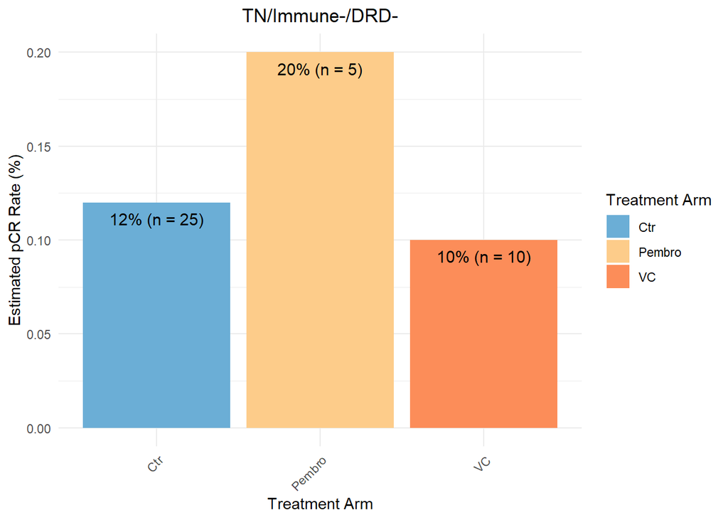

```r
# Bar plots

# 4 Bar plot for each group respecively; "Immune_neg_DRD_neg", "Immune_neg_DRD_pos" ,"Immune_pos_DRD_neg_count" and Immune_pos_DRD_pos_count.

# Function to create the bar plot
create_bar_plot <- function(data_subset, title) {
  # Calculate the mean pCR rate and counts
  pCR_rates <- aggregate(pCR ~ Arm..short.name., data = data_subset, FUN = mean)
  pCR_rates$Counts <- table(data_subset$Arm..short.name.)[pCR_rates$Arm..short.name.]

  # Filter for specified treatment arms
  pCR_rates <- pCR_rates[pCR_rates$Arm..short.name. %in% c("Ctr", "VC", "Pembro"),]

  # Create the bar plot
  bar_plot <- ggplot(pCR_rates, aes(x = Arm..short.name., y = pCR, fill = Arm..short.name.)) +
    geom_bar(stat = "identity") +
    geom_text(aes(label = ifelse(round(pCR * 100) > 0,
                                 paste0(round(pCR * 100), "% (n = ", Counts, ")"),
                                 "")),
              position = position_dodge(width = 0.9), vjust = 1.8, color = "black", size = 4) +
    scale_fill_manual(values = c("#6BAED6", "#FDCC8A", "#FC8D59")) +
    labs(x = "Treatment Arm", y = "Estimated pCR Rate (%)", fill = "Treatment Arm") +
    theme_minimal() +
    theme(axis.text.x = element_text(angle = 45, hjust = 1)) +
    ggtitle(title) +
    theme(plot.title = element_text(hjust = 0.5))

  return(bar_plot)
}

# Apply the function for the two subsets
bar_plot1 <- create_bar_plot(clin_TN[clin_TN$RPS.5 == "HER2-/Immune-/DRD.v3-",], "TN/Immune-/DRD-")
bar_plot2 <- create_bar_plot(clin_TN[clin_TN$RPS.5 == "HER2-/Immune-/DRD.v3+",], "TN/Immune-/DRD+")
bar_plot3 <- create_bar_plot(clin_TN[clin_TN$RPS.5 == "HER2-/Immune+" & clin_TN$DRD. == "0",],"TN/HER2-/Immune+/DRD-")
bar_plot4 <- create_bar_plot(clin_TN[clin_TN$RPS.5 == "HER2-/Immune+" & clin_TN$DRD. == "1",],"TN/HER2-/Immune+/DRD+")


# Print the bar plots
print(bar_plot1)
```

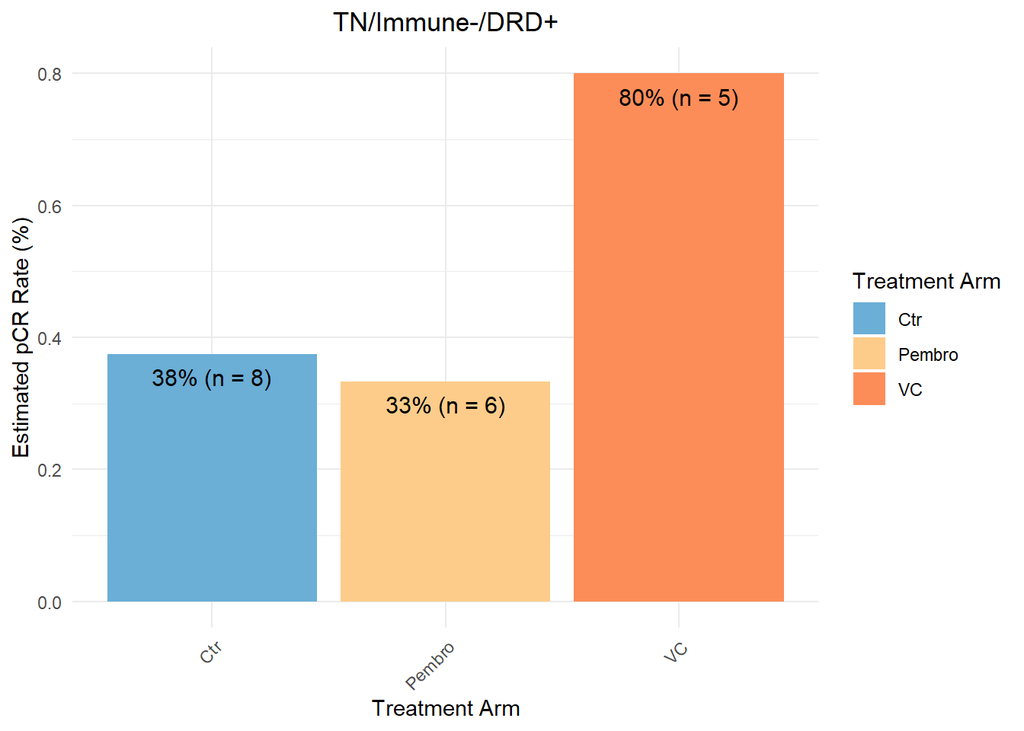

```r
print(bar_plot2)
```

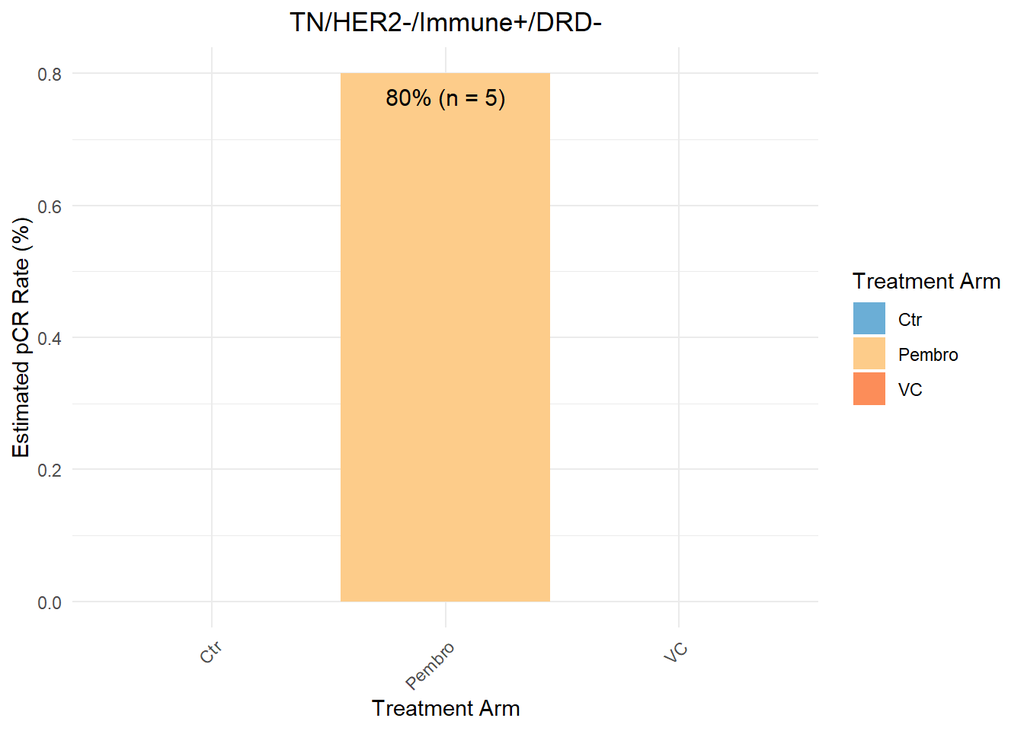

```r
print(bar_plot3)
```

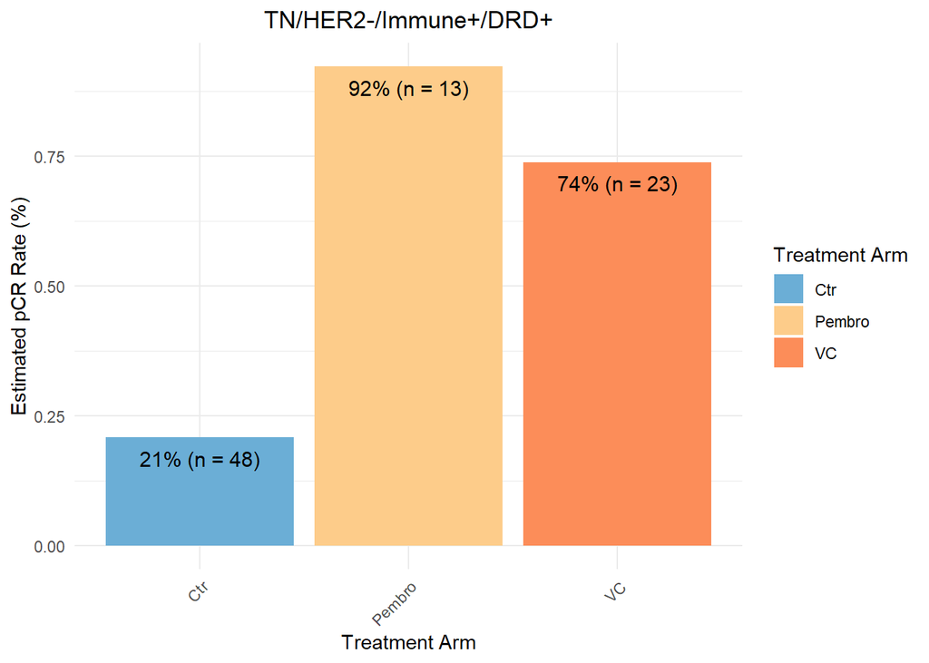

```r
print(bar_plot4)
```

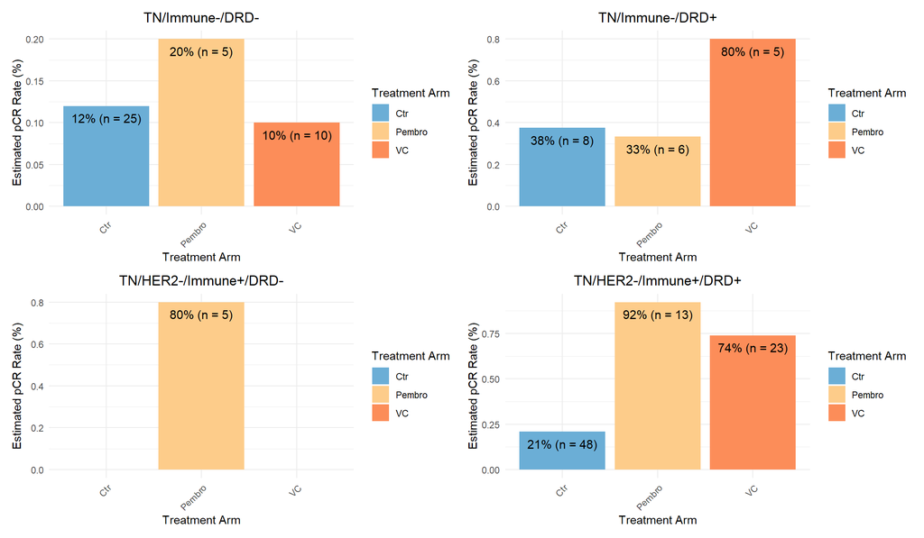

```r
# Combine the Bra plots ()
print(bar_plot1+ bar_plot2 + bar_plot3+ bar_plot4)
```

**Part(d)**:

**Sankey plot showing Immune/DRD subsets in HR+HER2-**

**Results**: Comparing our findings to those from paper Figure 4(d):

```r
# Use HR+HER2- subset

# Define counts.
clin_HR_pos_HER_neg  <- clin[clin$Receptor.Subtype == "HR+HER2-",]
Immune_neg_DRD_neg_count2 <- sum(clin_HR_pos_HER_neg$RPS.5 == "HER2-/Immune-/DRD.v3-", na.rm = TRUE)
Immune_neg_DRD_pos_count2 <- sum(clin_HR_pos_HER_neg$RPS.5 == "HER2-/Immune-/DRD.v3+", na.rm = TRUE)
Immune_pos_DRD_neg_count2 <- sum(clin_HR_pos_HER_neg$RPS.5 == "HER2-/Immune+" & clin_HR_pos_HER_neg$DRD. == "0", na.rm = TRUE)
Immune_pos_DRD_pos_count2 <- sum(clin_HR_pos_HER_neg$RPS.5 == "HER2-/Immune+"& clin_HR_pos_HER_neg$DRD. == "1", na.rm = TRUE)

# Example format: "HR-HER2+; 30% (n=100)"
nodes <- data.frame(name = c(
  paste("HR+HER2- ;","(n=",  nrow(clin_HR_pos_HER_neg), ")", sep=""),
  paste("HR+HER2-/Immune-/DRD+;", ceiling(Immune_neg_DRD_neg_count2  / nrow(clin_HR_pos_HER_neg) * 100), "% (n=", Immune_neg_DRD_neg_count, ")", sep=""),
  paste("HR+HER2-/Immune-/DRD-;", ceiling(Immune_neg_DRD_pos_count2 / nrow(clin_HR_pos_HER_neg) * 100), "% (n=", Immune_neg_DRD_pos_count, ")", sep=""),
  paste("HR+HER2-/Immune+/DRD-;", ceiling(Immune_pos_DRD_neg_count2 / nrow(clin_HR_pos_HER_neg) * 100), "% (n=", Immune_pos_DRD_neg_count, ")", sep=""),
   paste("HR+HER2-/Immune+/DRD+;", ceiling(Immune_pos_DRD_pos_count / nrow(clin_HR_pos_HER_neg) * 100), "% (n=", Immune_pos_DRD_pos_count, ")", sep="")
))

# Sample data for links
links <- data.frame(source = c(0, 0, 0, 0),
                    target = c(1, 2, 3, 4),
                    value = c(51, 10, 20, 19))

# Create the Sankey diagram
sankey <- sankeyNetwork(Links = links, Nodes = nodes, Source = 'source',
                        Target = 'target', Value = 'value', NodeID = 'name',
                        units = '%', fontSize = 12, nodeWidth = 18 )

# Print the Sankey diagram
sankey
```

[interactive chart not shown]

**Part(e)**:

**Results**: Comparing our findings to those from paper Figure 4(e):

- We observe that the bar plot results contain the exact same information as Figure 4(e) in the paper.

```r
# Subset clin for "HER2+"
clin_HER2_pos <- clin[clin$Receptor.Subtype == "HR-HER2+"| clin$Receptor.Subtype == "HR+HER2+",]


# Define count of "HR-HER2+", "HR+HER2", "HER2+/BP-HER2_or_Basal" , ""HER2+/BP-Luminal" an dTotal number of rows for defining the percentages.
hr_neg_count <- sum(clin_HER2_pos$Receptor.Subtype == "HR-HER2+")
hr_pos_count <- sum(clin_HER2_pos$Receptor.Subtype == "HR+HER2+")
BP_HER2_or_Basal_count <- sum(clin_HER2_pos$BP.HER2.2..4 == "HER2+/BP_Her2orBasal", na.rm = TRUE)
BP_Luminal_count <- sum(clin_HER2_pos$BP.HER2.2..4 == "HER2+/BP_Luminal", na.rm = TRUE)
total_count <- nrow(clin_HER2_pos)


# Example format: "HR-HER2+; 30% (n=100)"
nodes <- data.frame(name = c(
  paste("HR-HER2+;", round(hr_neg_count / total_count * 100), "% (n=", hr_neg_count , ")", sep=""),
  paste("HR+HER2+;", round(hr_pos_count / total_count * 100), "% (n=", hr_pos_count, ")", sep=""),
  paste("HER2+/BP-HER2_or_Basal;", round(BP_HER2_or_Basal_count / total_count * 100), "% (n=", BP_HER2_or_Basal_count, ")", sep=""),
  paste("HER2+/BP-Luminal;", round(BP_Luminal_count / total_count * 100), "% (n=", BP_Luminal_count, ")", sep="")
))

# Sample data for links
links <- data.frame(source = c(0, 0, 1, 1),
                    target = c(2, 3, 2, 3),
                    value = c(36, 1, 76, 24))

# Create the Sankey diagram
sankey <- sankeyNetwork(Links = links, Nodes = nodes, Source = 'source',
                        Target = 'target', Value = 'value', NodeID = 'name',
                        units = '%', fontSize = 12, nodeWidth = 18)

# Print the Sankey diagram
sankey
```

[interactive chart not shown]

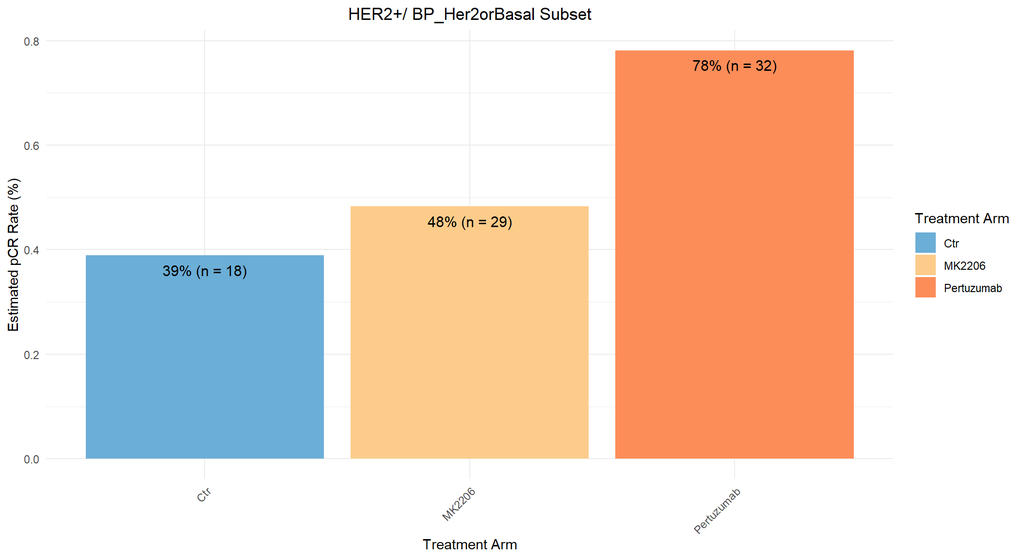

```r
# 1. bar_plot1 "HER2_pos_BP_Her2orBasal" group

# Filter clin_HER2_pos to include only the desired condition
clin_HER2_pos_BP_Her2orBasal <- clin_HER2_pos[clin_HER2_pos$BP.HER2.2..4 == "HER2+/BP_Her2orBasal",]

# Calculate the mean pCR rate for each treatment arm and receptor subtype
pCR_rate <- aggregate(pCR ~ Arm..short.name., data = clin_HER2_pos_BP_Her2orBasal, FUN = mean)

# Calculate the number of occurrences for each arm and add it to pCR_rate
pCR_rate$Counts <- table(clin_HER2_pos_BP_Her2orBasal$Arm..short.name.)[pCR_rate$Arm..short.name.]


# Keeping only 3 arms "Ctr", "MK2206", "Pertuzumab"
selected_arms <- c("Ctr", "MK2206", "Pertuzumab")
pCR_rate <- pCR_rate[pCR_rate$Arm..short.name. %in% selected_arms,]


# Define a ggplot object with a bar plot
bar_plot1 <- ggplot(pCR_rate, aes(x = Arm..short.name., y = pCR, fill = Arm..short.name.)) +
  geom_bar(stat = "identity") +
  geom_text(aes(label = paste0(round(pCR * 100),  "% (n = ", Counts, ")")),
            position = position_dodge(width = 0.9),
            vjust = 1.8,
            color = "black",
            size = 4) +
  scale_fill_manual(values = c("#6BAED6", "#FDCC8A", "#FC8D59")) +
  labs(x = "Treatment Arm", y = "Estimated pCR Rate (%)", fill = "Treatment Arm") +
  theme_minimal() +
  theme(axis.text.x = element_text(angle = 45, hjust = 1)) +
  ggtitle("HER2+/ BP_Her2orBasal Subset") +
  theme(plot.title = element_text(hjust = 0.5))


# Print the bar plot
print(bar_plot1)
```

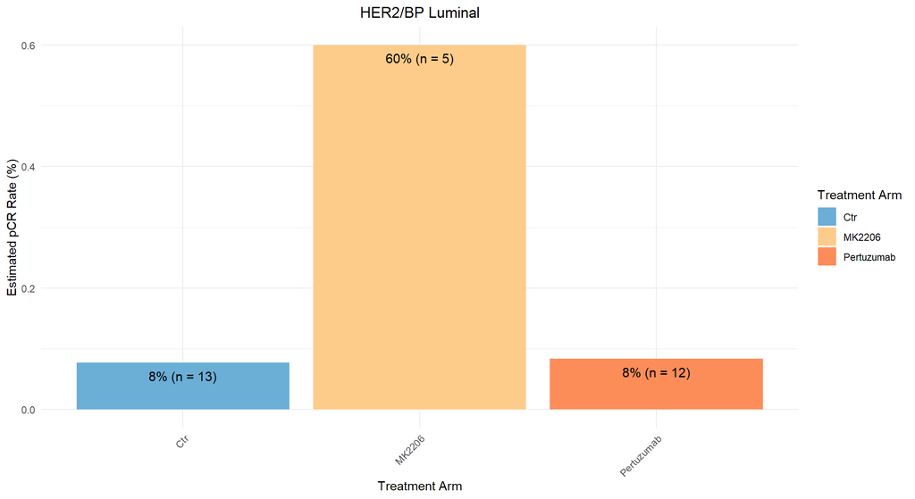

```r
# 2. 1. bar_plot1 "HER2/BP Luminal" group

# Filter clin_HER2_pos to include only the desired condition
clin_HER2_pos_BP_Luminall <- clin_HER2_pos[clin_HER2_pos$BP.HER2.2..4 == "HER2+/BP_Luminal",]

# Calculate the mean pCR rate for each treatment arm and receptor subtype
pCR_rate2 <- aggregate(pCR ~ Arm..short.name., data = clin_HER2_pos_BP_Luminall, FUN = mean)

# Filter pCR_rate2 for specific arms
pCR_rate2 <- pCR_rate2[pCR_rate2$Arm..short.name. %in% selected_arms,]

# Calculate the number of occurrences for each arm and add it to pCR_rate
pCR_rate2$Counts2 <- table(clin_HER2_pos_BP_Luminall$Arm..short.name.)[pCR_rate$Arm..short.name.]

# Define a ggplot object with a bar plot
bar_plot2 <- ggplot(pCR_rate2, aes(x = Arm..short.name., y = pCR, fill = Arm..short.name.)) +
  geom_bar(stat = "identity") +
  geom_text(aes(label = paste0(round(pCR * 100), "% (n = ", Counts2, ")")),
            position = position_dodge(width = 0.9),
            vjust = 1.8,
            color = "black",
            size = 4) +
  scale_fill_manual(values = c("#6BAED6", "#FDCC8A", "#FC8D59")) +  # Adjust colors if necessary
  labs(x = "Treatment Arm", y = "Estimated pCR Rate (%)", fill = "Treatment Arm") +
  theme_minimal() +
  theme(axis.text.x = element_text(angle = 45, hjust = 1)) +
  ggtitle("HER2/BP Luminal") +
  theme(plot.title = element_text(hjust = 0.5))

# Print the bar plot
print(bar_plot2)
```

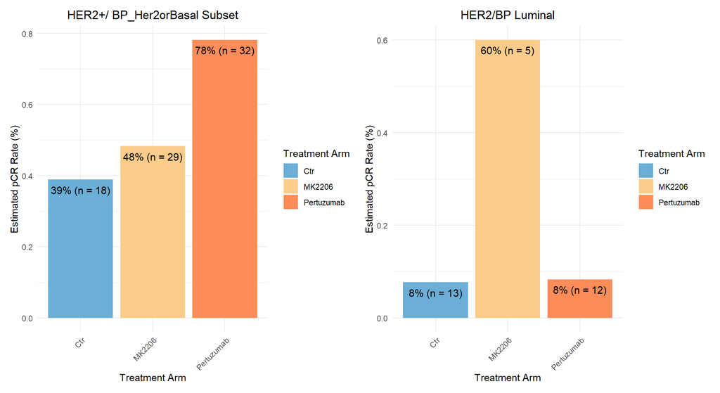

```r
# Combine Figure 4e graphs
print(bar_plot1 + bar_plot2)
```